# Big_Mart

Shikhar Dhwaj

15 October 2017

# Reading Input files

```r
train <- read.csv('D:/kaggle_comp/Big_Mart/Train_UWu5bXk.csv',header=T,na.strings = c('','NA'))
test <- read.csv('D:/kaggle_comp/Big_Mart/Test_u94Q5KV.csv',header=T,na.strings = c('','nA'))
```

# Combine the files into single data file

```r
test$Item_Outlet_Sales <- NA
full_data <- rbind(train,test)
```

# Data Exploration

### Checking the Dimensions

```r
dim(full_data)
```

```
## [1] 14204    12
```

```r
dim(train)
```

```
## [1] 8523   12
```

```r
dim(test)
```

```
## [1] 5681   12
```

### Checking for missing values

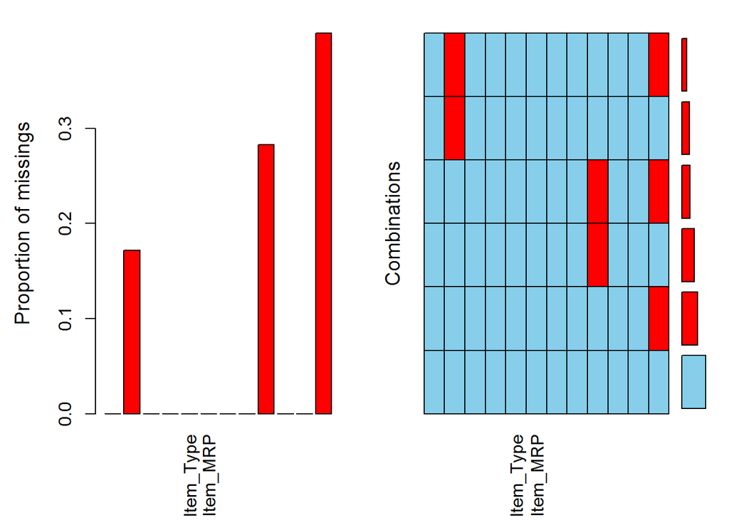

```r
library(VIM)
aggr(full_data)
```

**Apart from Item_Outlet_Sales only Item_Weight and Outlet_Size have missing values**

### Examining each quantitative variable

```r
nq <- c('Item_Weight','Item_Visibility','Item_MRP','Item_Outlet_Sales','Outlet_Establishment_Year')
sapply(nq,function(a){summary(full_data[a])})
```

```
## $Item_Weight
##   Item_Weight
##  Min.   : 4.555
##  1st Qu.: 8.710
##  Median :12.600
##  Mean   :12.793
##  3rd Qu.:16.750
##  Max.   :21.350
##  NA's   :2439
##
## $Item_Visibility
##  Item_Visibility
##  Min.   :0.00000
##  1st Qu.:0.02704
##  Median :0.05402
##  Mean   :0.06595
##  3rd Qu.:0.09404
##  Max.   :0.32839
##
## $Item_MRP
##     Item_MRP
##  Min.   : 31.29
##  1st Qu.: 94.01
##  Median :142.25
##  Mean   :141.00
##  3rd Qu.:185.86
##  Max.   :266.89
##
## $Item_Outlet_Sales
##  Item_Outlet_Sales
##  Min.   :   33.29
##  1st Qu.:  834.25
##  Median : 1794.33
##  Mean   : 2181.29
##  3rd Qu.: 3101.30
##  Max.   :13086.97
##  NA's   :5681
##
## $Outlet_Establishment_Year
##  Outlet_Establishment_Year
##  Min.   :1985
##  1st Qu.:1987
##  Median :1999
##  Mean   :1998
##  3rd Qu.:2004
##  Max.   :2009
```

### Better understanding provided by boxplot

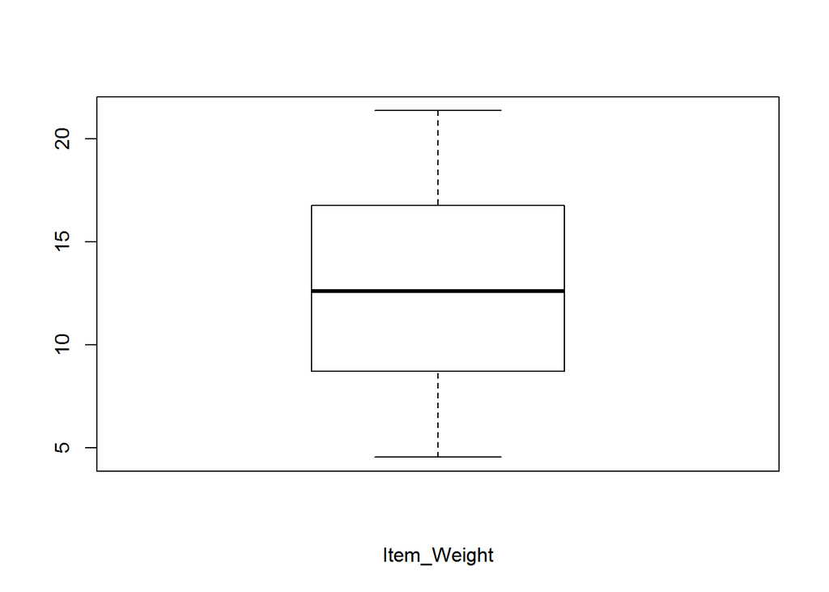

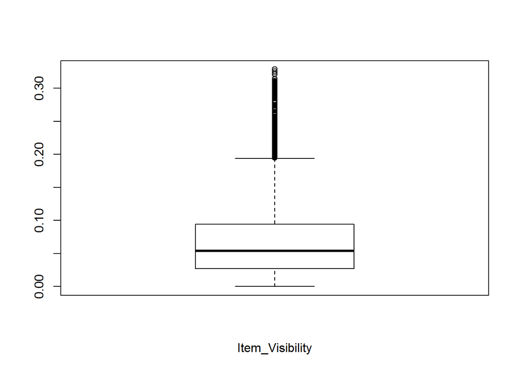

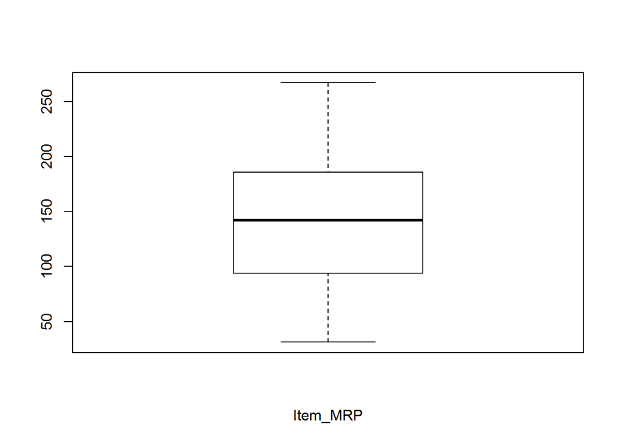

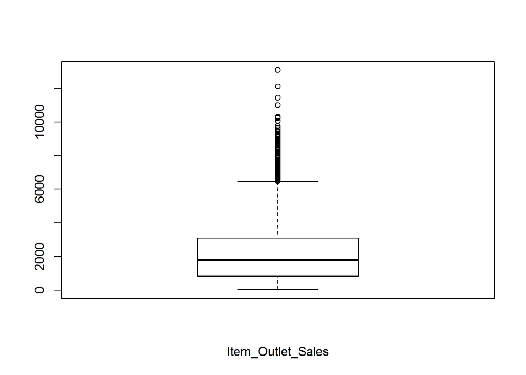

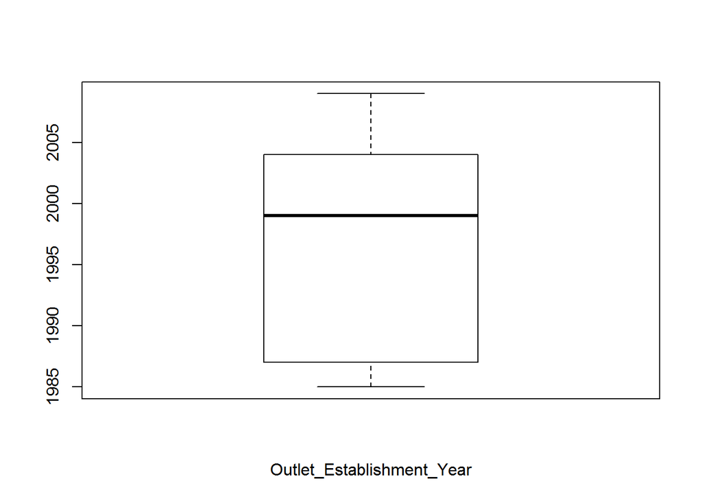

```
##       Item_Weight Item_Visibility Item_MRP  Item_Outlet_Sales
## stats Numeric,5   Numeric,5       Numeric,5 Numeric,5
## n     11765       14204           14204     8523
## conf  Numeric,2   Numeric,2       Numeric,2 Numeric,2
## out   Numeric,0   Numeric,261     Numeric,0 Numeric,186
## group Numeric,0   Numeric,261     Numeric,0 Numeric,186
## names ""          ""              ""        ""
##       Outlet_Establishment_Year
## stats Numeric,5
## n     14204
## conf  Numeric,2
## out   Numeric,0
## group Numeric,0
## names ""
```

```r
sapply(nq,function(a){boxplot(full_data[,a],xlab = a)})
```

### Key Observations

**There are Outliers present in Item Visibility and Item_Outlet_Sales**  
**Item Visibility has min value 0 , which makes no sense**  
**If Outlet_Establishment_Year is converted into how long a particular store has been, then it will have better impact on sales**

### Examining Categorical Variables

```r
nc <- c('Item_Fat_Content','Item_Type','Outlet_Identifier','Outlet_Size','Outlet_Location_Type','Outlet_Type')
sapply(nc,function(x){table(full_data[,x])})
```

```
## $Item_Fat_Content
##
##      LF low fat Low Fat     reg Regular
##     522     178    8485     195    4824
##
## $Item_Type
##
##          Baking Goods                Breads             Breakfast
##                  1086                   416                   186
##                Canned                 Dairy          Frozen Foods
##                  1084                  1136                  1426
## Fruits and Vegetables           Hard Drinks    Health and Hygiene
##                  2013                   362                   858
##             Household                  Meat                Others
##                  1548                   736                   280
##               Seafood           Snack Foods           Soft Drinks
##                    89                  1989                   726
##         Starchy Foods
##                   269
##
## $Outlet_Identifier
##
## OUT010 OUT013 OUT017 OUT018 OUT019 OUT027 OUT035 OUT045 OUT046 OUT049
##    925   1553   1543   1546    880   1559   1550   1548   1550   1550
##
## $Outlet_Size
##
##   High Medium  Small
##   1553   4655   3980
##
## $Outlet_Location_Type
##
## Tier 1 Tier 2 Tier 3
##   3980   4641   5583
##
## $Outlet_Type
##
##     Grocery Store Supermarket Type1 Supermarket Type2 Supermarket Type3
##              1805              9294              1546              1559
```

### Key Observations

**Low fat have been coded as LF ,low fat and Low Fat**  
**Regular has been coded as Regular as reg**  
**Too many categories in Item_type**

# Data Cleaning

### Imputing missing values in Item_Weight

```r
full_data$Item_Weight[is.na(full_data$Item_Weight)] <- mean(full_data$Item_Weight,na.rm = T)
table(is.na(full_data$Item_Weight))
```

```
##
## FALSE
## 14204
```

### Imputing missing values in Outlet_Size with mode wrt Outlet type

```r
table(full_data$Outlet_Size,full_data$Outlet_Type)
```

```
##
##          Grocery Store Supermarket Type1 Supermarket Type2
##   High               0              1553                 0
##   Medium             0              1550              1546
##   Small            880              3100                 0
##
##          Supermarket Type3
##   High                   0
##   Medium              1559
##   Small                  0
```

```r
full_data$Outlet_Size[is.na(full_data$Outlet_Size)&(full_data$Outlet_Type=='Grocery Store')] <- 'Small'
full_data$Outlet_Size[is.na(full_data$Outlet_Size)&(full_data$Outlet_Type=='Supermarket Type1')] <- 'Small'
full_data$Outlet_Size[is.na(full_data$Outlet_Size)&(full_data$Outlet_Type=='Supermarket Type2')] <- 'Medium'
full_data$Outlet_Size[is.na(full_data$Outlet_Size)&(full_data$Outlet_Type=='Supermarket Type3')] <- 'Medium'
```

# Feature Engineering

### 1. Consider Combining the Outlet_Type Variable

**Examine Mean Item Outlet Sales wrt Outlet_Type**

```r
aggregate(Item_Outlet_Sales~Outlet_Type,data=full_data,FUN = mean,na.rm=T)
```

```
##         Outlet_Type Item_Outlet_Sales
## 1     Grocery Store          339.8285
## 2 Supermarket Type1         2316.1811
## 3 Supermarket Type2         1995.4987
## 4 Supermarket Type3         3694.0386
```

**There is significant difference between type 2 and type 3 , hence we will leave them as it is**

### 2. Modify Item Visibility

**We had earlier observed items with visibility 0. We will replace it with mean value of visibility for each item**

```r
## Exclude 0 in another attempt and see the impact
a<-data.frame(aggregate(Item_Visibility~Item_Identifier,data=full_data,FUN = mean,na.rm=T))
w <- which(full_data$Item_Visibility==0)
for(i in w)
{
  value <- a$Item_Visibility[a$Item_Identifier==full_data$Item_Identifier[i]]
  full_data$Item_Visibility[w] <- value
  }
```

### 3. Create a new feature Item_Visibility_Ratio that compares visibility of Item in particular store and its overall mean visibility across all stores

```r
full_data$Item_Visibility_Ratio <- full_data$Item_Visibility/a$Item_Visibility[full_data$Item_Identifier]
```

### 4. Create Broad Category of Item_Type

```r
table(full_data$Item_Type)
```

```
##
##          Baking Goods                Breads             Breakfast
##                  1086                   416                   186
##                Canned                 Dairy          Frozen Foods
##                  1084                  1136                  1426
## Fruits and Vegetables           Hard Drinks    Health and Hygiene
##                  2013                   362                   858
##             Household                  Meat                Others
##                  1548                   736                   280
##               Seafood           Snack Foods           Soft Drinks
##                    89                  1989                   726
##         Starchy Foods
##                   269
```

```r
# Too many Categories
# ID variable has information about product type
# FD = Food , DR = drink , NC = Non Consumables
full_data$Item_Type_Combined <- substr(full_data$Item_Identifier,1,2)
table(full_data$Item_Type_Combined,full_data$Item_Type)
```

```
##
##      Baking Goods Breads Breakfast Canned Dairy Frozen Foods
##   DR            0      0         0      0   229            0
##   FD         1086    416       186   1084   907         1426
##   NC            0      0         0      0     0            0
##
##      Fruits and Vegetables Hard Drinks Health and Hygiene Household Meat
##   DR                     0         362                  0         0    0
##   FD                  2013           0                  0         0  736
##   NC                     0           0                858      1548    0
##
##      Others Seafood Snack Foods Soft Drinks Starchy Foods
##   DR      0       0           0         726             0
##   FD      0      89        1989           0           269
##   NC    280       0           0           0             0
```

**After observing the table we conclude that our proposal of Item Combination was correct**

### 5. Change Years of Operation Column

```r
# Focusing on how old the store is
full_data$Outlet_Years <- 2013 - full_data$Outlet_Establishment_Year
```

### 6. Modify categories of Fat Content

```r
table(full_data$Item_Fat_Content)
```

```
##
##      LF low fat Low Fat     reg Regular
##     522     178    8485     195    4824
```

```r
levels(full_data$Item_Fat_Content)[levels(full_data$Item_Fat_Content)=="LF"] <- "Low Fat"
levels(full_data$Item_Fat_Content)[levels(full_data$Item_Fat_Content)=="low fat"] <- "Low Fat"
levels(full_data$Item_Fat_Content)[levels(full_data$Item_Fat_Content)=="reg"] <- "Regular"
```

### 7. Non Consumable product should not be fat ,so it should be defined as Non-Edible

```r
levels(full_data$Item_Fat_Content) <- c(levels(full_data$Item_Fat_Content),'Non-Edible')
full_data$Item_Fat_Content[full_data$Item_Fat_Content=="Low Fat" & full_data$Item_Type_Combined=='NC'] <- 'Non-Edible'
```

# Remove Modified Columns

```r
name <- c('Item_Identifier','Item_Type','Outlet_Establishment_Year','Outlet_Identifier')
full_data <- full_data[,!names(full_data) %in% name]
```

# One Hot Encoding

```r
library(ade4)
fea <- c('Item_Fat_Content','Outlet_Size','Outlet_Location_Type','Outlet_Type','Item_Type_Combined')
for (f in fea){
  df_all_dummy = acm.disjonctif(full_data[f])
  full_data[f] = NULL
  full_data = cbind(full_data, df_all_dummy)
}
```

# Normalization

```r
scaled.data <- scale(full_data[,c(1,2,3,5,6)])
full_data <- cbind(scaled.data,full_data[,c(7:22,4)])
```

# Split the data

```r
train.data <- full_data[1:8523,]
test.data <-full_data[8524:14204,]
```

# Linear Regression

```r
fit <- lm(Item_Outlet_Sales~.,data = train.data)
library(leaps)
sub.fit = regsubsets(Item_Outlet_Sales~., data=train.data)
```

```
## Reordering variables and trying again:
```

```r
best.summary <- summary(sub.fit)

which.min(best.summary$rss)
```

```
## [1] 9
```

# Feature Selection

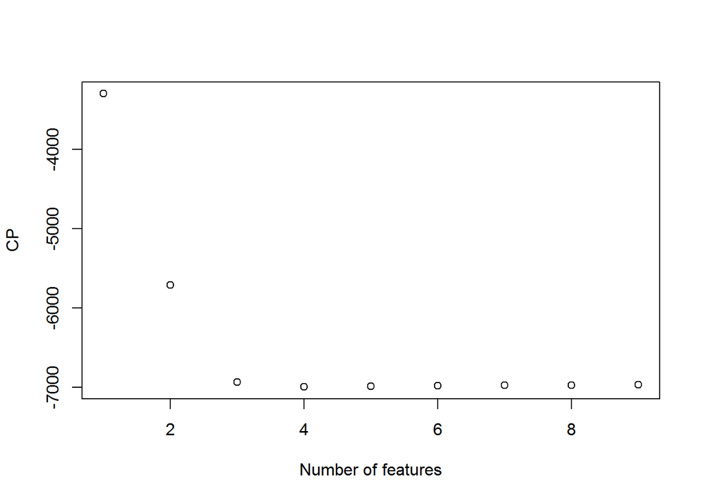

```r
plot(best.summary$bic,xlab='Number of features',ylab='CP')
```

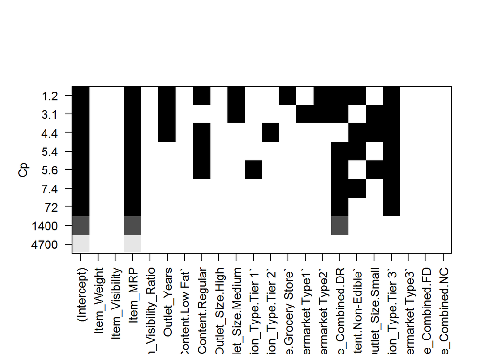

```r
plot(sub.fit,scale = 'Cp')
```

```r
which.max(best.summary$adjr2)
```

```
## [1] 9
```

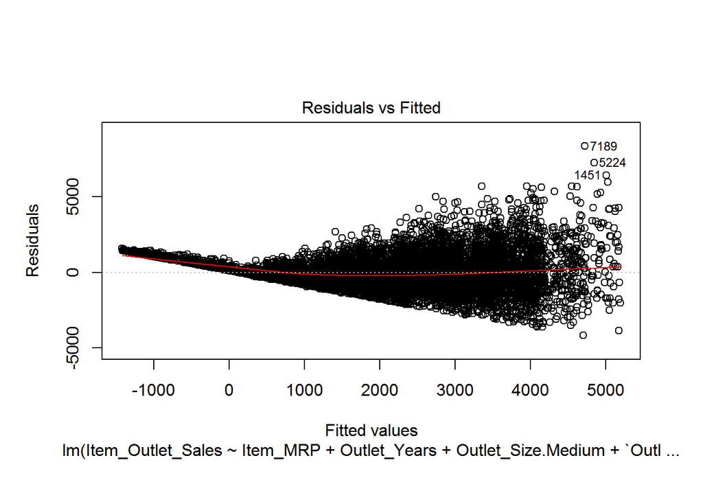

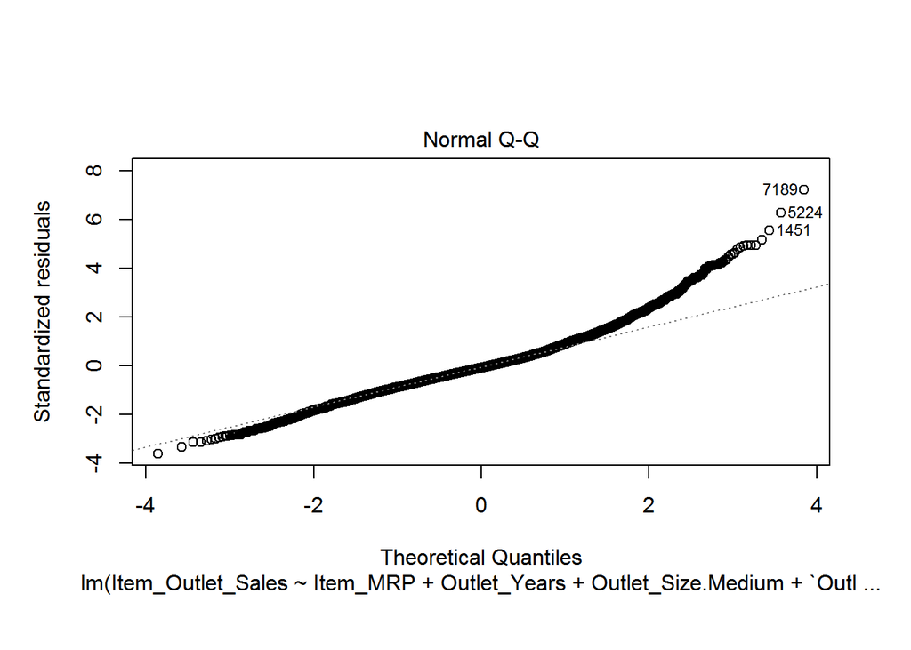

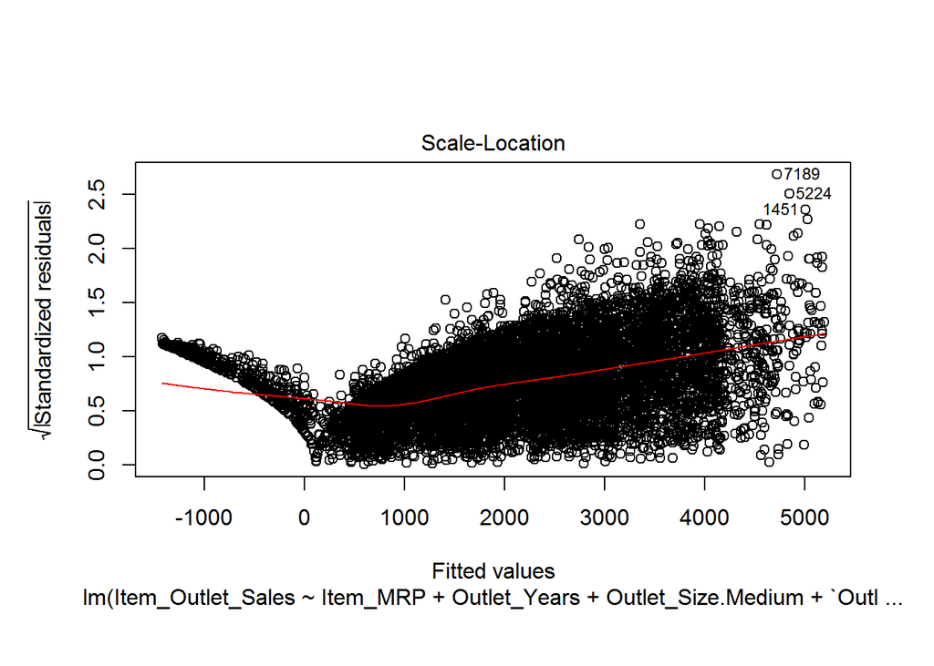

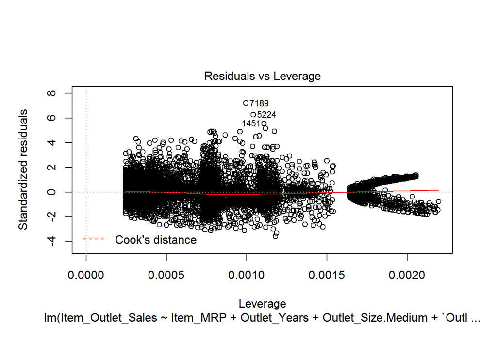

```r
try.fit <- lm(Item_Outlet_Sales~Item_MRP + Outlet_Years  + Outlet_Size.Medium + `Outlet_Type.Grocery Store` + `Outlet_Type.Supermarket Type2`  + `Outlet_Location_Type.Tier 3`,data=train.data)
plot(try.fit)
```

```r
error <- try.fit$fitted.values - train.data$Item_Outlet_Sales
sqrt(mean(error^2))
```

```
## [1] 1158.859
```

```r
p <- predict(try.fit,test.data[,c(3,5,10,15,17,14)])
```